# Project Description

Fraud in the banking sector does not only lead to financial losses, but it can also damage a company’s reputation and weaken customer trust. In this project, we aim to detect suspicious banking transactions, highlight hidden anomalies, and help protect the integrity of financial systems.

Our goal is to identify transactions that look unusual or do not follow typical patterns. These may be early signs of fraudulent behavior. By analyzing this data, we can support the organization in taking quick action, improving security, and maintaining the confidence of its customers.

To do this, we will use the **Isolation Forest (IForest)** algorithm from the `pyod.models` library. This model is designed to detect outliers in large datasets and is well-suited for finding rare and suspicious events.

Our task involves:

- Applying the IForest model to transaction data.
- Identifying anomalies that could innicate potential fraud.
- Summarizing the results to provide clear insights.
- Supporting the company in making faster and better fraud-related decisions.

By the end of this project, we aim to provide a reliable method for monitoring transactions and reducing the risk of fraud through early detection and meanigful insights.

## The Data

We will work with a dataset containing information about financial transactions. Below is a summary of the key columns provided:

| **Column** | **Description** |
| --- | --- |
| `TransactionID` | A unique identifier for each transaction. |
| `TransactionAmount` | The amount of money involved in the transaction (in USD). |
| `TransactionDuration` | Duration of the transaction (in seconds). |
| `AccountBalance` | The balance of the account after the transaction was processed (in USD). |

```python
# Import required libraries
import pandas as pd
import numpy as np
from pyod.models.iforest import IForest
import matplotlib.pyplot as plt
import seaborn as sns

# Load the dataset
transactions = pd.read_csv("transactions.csv")

# Isolate key columns
columns = ["TransactionID", "TransactionAmount", "TransactionDuration", "AccountBalance"]
transactions = transactions[columns]

# Display the first rows
transactions.head()
```

|  | TransactionID | TransactionAmount | TransactionDuration | AccountBalance |
| --- | --- | --- | --- | --- |
| 0 | TX000001 | 14.09 | 81 | 5112.21 |
| 1 | TX000002 | 376.24 | 141 | 13758.91 |
| 2 | TX000003 | 126.29 | 56 | 1122.35 |
| 3 | TX000004 | 184.50 | 25 | 8569.06 |
| 4 | TX000005 | 13.45 | 198 | 7429.40 |

### Compute an anomaly score for each transaction.

```python
# Select numerical features for anomaly detection
features = transactions[["TransactionAmount", "TransactionDuration", "AccountBalance"]]

# Train an IForest model
model = IForest(n_estimators=100, contamination=0.05, random_state=42)
model.fit(features)

# Add the anomaly scores to the dataset
transactions["Anomaly_Score"] = model.decision_function(features)

transactions.head()
```

|  | TransactionID | TransactionAmount | TransactionDuration | AccountBalance | Anomaly_Score |
| --- | --- | --- | --- | --- | --- |
| 0 | TX000001 | 14.09 | 81 | 5112.21 | -0.127230 |
| 1 | TX000002 | 376.24 | 141 | 13758.91 | -0.043850 |
| 2 | TX000003 | 126.29 | 56 | 1122.35 | -0.150263 |
| 3 | TX000004 | 184.50 | 25 | 8569.06 | -0.105860 |
| 4 | TX000005 | 13.45 | 198 | 7429.40 | -0.096070 |

### Which transactions are flagged as anomalies?

```python
# Flag transactions as anomalies based on the model's prediction
transactions["Anomaly"] = (model.predict(features) == 1).astype(int)

transactions.head()
```

|  | TransactionID | TransactionAmount | TransactionDuration | AccountBalance | Anomaly_Score | Anomaly |
| --- | --- | --- | --- | --- | --- | --- |
| 0 | TX000001 | 14.09 | 81 | 5112.21 | -0.127230 | 0 |
| 1 | TX000002 | 376.24 | 141 | 13758.91 | -0.043850 | 0 |
| 2 | TX000003 | 126.29 | 56 | 1122.35 | -0.150263 | 0 |
| 3 | TX000004 | 184.50 | 25 | 8569.06 | -0.105860 | 0 |
| 4 | TX000005 | 13.45 | 198 | 7429.40 | -0.096070 | 0 |

### Create a summary of anomalous transactions.

```python
# summary of anomalous transactions
anomalies_summary = transactions.loc[transactions["Anomaly"] == 1, ["TransactionID", "TransactionAmount", "TransactionDuration", "AccountBalance"]]

anomalies_summary.head()
```

|  | TransactionID | TransactionAmount | TransactionDuration | AccountBalance |
| --- | --- | --- | --- | --- |
| 41 | TX000042 | 34.02 | 19 | 14214.48 |
| 74 | TX000075 | 1212.51 | 24 | 605.95 |
| 85 | TX000086 | 1340.19 | 30 | 8654.28 |
| 141 | TX000142 | 1049.92 | 21 | 2037.85 |
| 146 | TX000147 | 973.39 | 296 | 2042.22 |

### What is the distribution of TransactionAmount for normal and anomalous transactions?

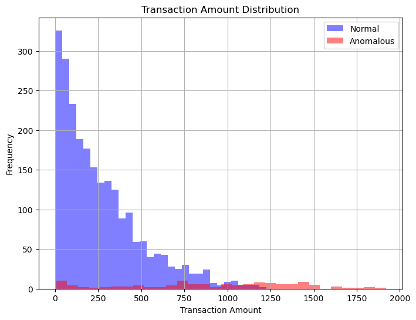

```python
# Plot the distribution of TransactionAmount for normal and anomalous transactions
plt.figure(figsize=(8, 6))
transactions[transactions["Anomaly"] == False]["TransactionAmount"].hist(bins=30, alpha=0.5, label="Normal", color="blue")
transactions[transactions["Anomaly"] == True]["TransactionAmount"].hist(bins=30, alpha=0.5, label="Anomalous", color="red")
plt.title("Transaction Amount Distribution")
plt.xlabel("Transaction Amount")
plt.ylabel("Frequency")
plt.legend()
plt.savefig("anomalies_histogram.png")
```